# Gym Customer Churn Prediction

## Comparison of classification methods: decision tree, random forest, XGBoost, kNN and logistic regression

The aim of this project is to create a classification model, to predict gym customer churn (identifying customers who are likely to resign in the upcoming month). The project includes a comparison of 5 classification models: decision tree, random forest, XGBoost, k-nearest neighbors and logistic regression. Then the best model is selected, taking into consideration model's performance on train and test dataset as well as its complexity and interpretability.  
Data used in the project comes from the Kaggle website. Link to the dataset: https://www.kaggle.com/datasets/adrianvinueza/gym-customers-features-and-churn/data.  
Dataset involves features such as e.g. demographic data, information if the client lives/works in the proximity of the gym, contract period, average additional charges and information, if client resigned from the gym membership.

# 1. Imports

```python
import pandas as pd
import numpy as np
import matplotlib.pyplot as plt
import seaborn as sns
import kagglehub
import os
from sklearn.model_selection import train_test_split, GridSearchCV
from sklearn.tree import DecisionTreeClassifier, plot_tree
from sklearn.metrics import confusion_matrix, accuracy_score, recall_score, classification_report
from scipy.stats import pointbiserialr
from imblearn.under_sampling import RandomUnderSampler
from sklearn.ensemble import RandomForestClassifier
from sklearn.neighbors import KNeighborsClassifier
from sklearn.preprocessing import StandardScaler
from sklearn.decomposition import PCA
from matplotlib.colors import ListedColormap
from sklearn.linear_model import LogisticRegression
from xgboost import XGBClassifier
import shap
```

# 2. Data - initial exploration of the dataset

```python
path = kagglehub.dataset_download(
    "adrianvinueza/gym-customers-features-and-churn"
)

df = pd.read_csv(os.path.join(path, "gym_churn_us.csv"))
```

### 2.1. Basic information about the dataset

```python
df.shape
```

```
(4000, 14)
```

```python
df.head(10)
```

|  | gender | Near_Location | Partner | Promo_friends | Phone | Contract_period | Group_visits | Age | Avg_additional_charges_total | Month_to_end_contract | Lifetime | Avg_class_frequency_total | Avg_class_frequency_current_month | Churn |
| --- | --- | --- | --- | --- | --- | --- | --- | --- | --- | --- | --- | --- | --- | --- |
| 0 | 1 | 1 | 1 | 1 | 0 | 6 | 1 | 29 | 14.227470 | 5.0 | 3 | 0.020398 | 0.000000 | 0 |
| 1 | 0 | 1 | 0 | 0 | 1 | 12 | 1 | 31 | 113.202938 | 12.0 | 7 | 1.922936 | 1.910244 | 0 |
| 2 | 0 | 1 | 1 | 0 | 1 | 1 | 0 | 28 | 129.448479 | 1.0 | 2 | 1.859098 | 1.736502 | 0 |
| 3 | 0 | 1 | 1 | 1 | 1 | 12 | 1 | 33 | 62.669863 | 12.0 | 2 | 3.205633 | 3.357215 | 0 |
| 4 | 1 | 1 | 1 | 1 | 1 | 1 | 0 | 26 | 198.362265 | 1.0 | 3 | 1.113884 | 1.120078 | 0 |
| 5 | 1 | 1 | 0 | 0 | 1 | 1 | 1 | 34 | 450.743960 | 1.0 | 3 | 2.623477 | 2.637007 | 0 |
| 6 | 1 | 1 | 1 | 1 | 0 | 6 | 1 | 32 | 94.266389 | 6.0 | 2 | 1.138941 | 1.277242 | 0 |
| 7 | 0 | 1 | 0 | 0 | 1 | 1 | 0 | 30 | 217.786641 | 1.0 | 0 | 1.213502 | 1.049387 | 1 |
| 8 | 1 | 1 | 1 | 1 | 1 | 1 | 1 | 23 | 45.409909 | 1.0 | 1 | 1.106239 | 1.059333 | 0 |
| 9 | 0 | 1 | 0 | 0 | 1 | 1 | 0 | 31 | 65.310836 | 1.0 | 11 | 1.810852 | 1.951368 | 0 |

Dataset consists of the following variables:

- **Gender** - customer's gender,
- **Near_Location** - if customer lives/works near the gym,
- **Partner** - if customer's company is the gym's partner,
- **Promo_friends** - if customer signed up because of a "bring a friend" campaign,
- **Phone** - if customer provided their telephone number,
- **Contract_period** - contract period in months,
- **Group_visits** - not explained in the dataset source - most likely if the customer attended group classes,
- **Age** - customer's age
- **Avg_additional_charghes_total** - average additional charghe per visit,
- **Month_to_end_contract** - months left until the end of the contract,
- **Lifetime** - customer's lifetime (a period of time the customer has been using the gym services), in months, brak informacji w źródle danych, najprawdopodobniej staż klienta, tj. liczba miesięcy, od których klient korzysta z usług,
- **Avg_class_frequency_total** - not explained in the dataset source, most likely an average number of classes attended by a customer during the whole membership (it was assumed that it's an average per week)
- **Avg_class_frequency_current_month** - not explained in the dataset source, most likely an average number of classes attended by a customer during the current month (it was assumed that it's an average per week)
- **Churn - if customer resigned from the gym membership by the end of the current month**

Ujednolicenie nazw zmiennych

```python
df.columns = df.columns.str.lower()
```

```python
df.info()
```

```
<class 'pandas.core.frame.DataFrame'>
RangeIndex: 4000 entries, 0 to 3999
Data columns (total 14 columns):
 #   Column                             Non-Null Count  Dtype
---  ------                             --------------  -----
 0   gender                             4000 non-null   int64
 1   near_location                      4000 non-null   int64
 2   partner                            4000 non-null   int64
 3   promo_friends                      4000 non-null   int64
 4   phone                              4000 non-null   int64
 5   contract_period                    4000 non-null   int64
 6   group_visits                       4000 non-null   int64
 7   age                                4000 non-null   int64
 8   avg_additional_charges_total       4000 non-null   float64
 9   month_to_end_contract              4000 non-null   float64
 10  lifetime                           4000 non-null   int64
 11  avg_class_frequency_total          4000 non-null   float64
 12  avg_class_frequency_current_month  4000 non-null   float64
 13  churn                              4000 non-null   int64
dtypes: float64(4), int64(10)
memory usage: 437.6 KB
```

### 2.2. Checking for missing values and duplicates

```python
df.isna().sum()
```

```
gender                               0
near_location                        0
partner                              0
promo_friends                        0
phone                                0
contract_period                      0
group_visits                         0
age                                  0
avg_additional_charges_total         0
month_to_end_contract                0
lifetime                             0
avg_class_frequency_total            0
avg_class_frequency_current_month    0
churn                                0
dtype: int64
```

```python
print(df.duplicated().sum())
```

```
0
```

Dataset consists of 4000 observations, there are no missing or duplicated values. Dataset involved 14 variables (7 binary variables, 7 numeric variables). Dependent variable is the binary variable *churn*.

### 2.3. Basic descriptive statistics

```python
df.describe().T
```

|  | count | mean | std | min | 25% | 50% | 75% | max |
| --- | --- | --- | --- | --- | --- | --- | --- | --- |
| gender | 4000.0 | 0.510250 | 0.499957 | 0.000000 | 0.000000 | 1.000000 | 1.000000 | 1.000000 |
| near_location | 4000.0 | 0.845250 | 0.361711 | 0.000000 | 1.000000 | 1.000000 | 1.000000 | 1.000000 |
| partner | 4000.0 | 0.486750 | 0.499887 | 0.000000 | 0.000000 | 0.000000 | 1.000000 | 1.000000 |
| promo_friends | 4000.0 | 0.308500 | 0.461932 | 0.000000 | 0.000000 | 0.000000 | 1.000000 | 1.000000 |
| phone | 4000.0 | 0.903500 | 0.295313 | 0.000000 | 1.000000 | 1.000000 | 1.000000 | 1.000000 |
| contract_period | 4000.0 | 4.681250 | 4.549706 | 1.000000 | 1.000000 | 1.000000 | 6.000000 | 12.000000 |
| group_visits | 4000.0 | 0.412250 | 0.492301 | 0.000000 | 0.000000 | 0.000000 | 1.000000 | 1.000000 |
| age | 4000.0 | 29.184250 | 3.258367 | 18.000000 | 27.000000 | 29.000000 | 31.000000 | 41.000000 |
| avg_additional_charges_total | 4000.0 | 146.943728 | 96.355602 | 0.148205 | 68.868830 | 136.220159 | 210.949625 | 552.590740 |
| month_to_end_contract | 4000.0 | 4.322750 | 4.191297 | 1.000000 | 1.000000 | 1.000000 | 6.000000 | 12.000000 |
| lifetime | 4000.0 | 3.724750 | 3.749267 | 0.000000 | 1.000000 | 3.000000 | 5.000000 | 31.000000 |
| avg_class_frequency_total | 4000.0 | 1.879020 | 0.972245 | 0.000000 | 1.180875 | 1.832768 | 2.536078 | 6.023668 |
| avg_class_frequency_current_month | 4000.0 | 1.767052 | 1.052906 | 0.000000 | 0.963003 | 1.719574 | 2.510336 | 6.146783 |
| churn | 4000.0 | 0.265250 | 0.441521 | 0.000000 | 0.000000 | 0.000000 | 1.000000 | 1.000000 |

**26% of customers resigned from the gym membership by the end of the analyzed month**.  
Dataset is not balanced with respect to *Churn* - the minority class (churned customers) is about 3 times smaller than the majority class (active customers).

# 3. EDA

## 3.1. Variable distributions

- numeric variables

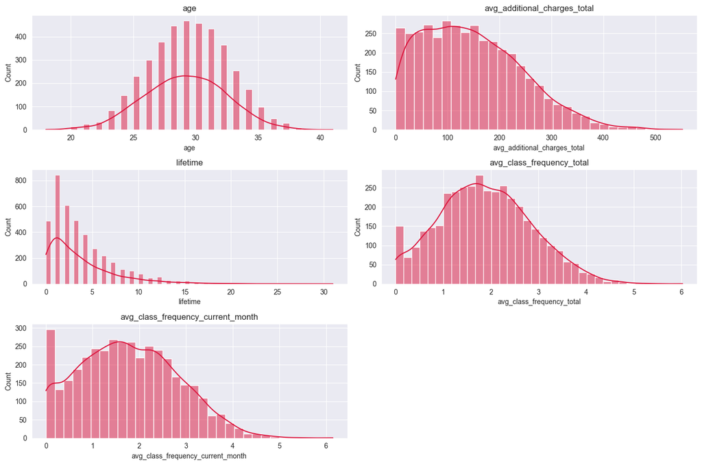

```python
sns.set_style("darkgrid")

numerical_columns = ['age',
       'avg_additional_charges_total', 'lifetime',
       'avg_class_frequency_total', 'avg_class_frequency_current_month']

plt.figure(figsize=(14, len(numerical_columns) * 3))
for idx, feature in enumerate(numerical_columns, 1):
    plt.subplot(len(numerical_columns), 2, idx)
    sns.histplot(df[feature], kde=True, color='crimson')
    plt.title(feature)

plt.tight_layout()
plt.show()
```

Variables with potential outliers: *avg_additional_charges_total*, *lifetime*, *avg_class_frequency_total*, *avg_class_frequency_current_month*.

- binary variables

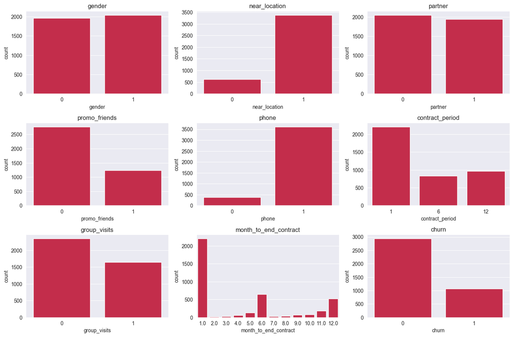

```python
sns.set_style("darkgrid")

cat_columns = [col for col in df.columns if col not in numerical_columns]

plt.figure(figsize=(14, len(cat_columns) * 3))
for idx, feature in enumerate(cat_columns, 1):
    plt.subplot(len(cat_columns), 3, idx)
    sns.countplot(data=df, x=feature,color='crimson')
    plt.title(feature)

plt.tight_layout()
plt.show()
```

## 3.2. Outlier detection

Outlier analysis was conducted only on the variables identified in the previous section as potentially including outliers.

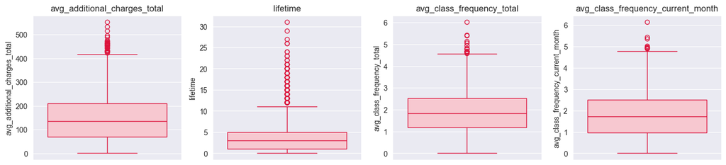

```python
sns.set_style("darkgrid")

outlier_columns = ['avg_additional_charges_total', 'lifetime',
       'avg_class_frequency_total', 'avg_class_frequency_current_month']

plt.figure(figsize=(14, len(outlier_columns) * 3))
for idx, feature in enumerate(outlier_columns, 1):
    plt.subplot(len(outlier_columns), 4, idx)
    sns.boxplot(
        data=df,
        y=feature,
        color='pink',
        boxprops=dict(edgecolor='crimson'),
        medianprops=dict(color='crimson'),
        whiskerprops=dict(color='crimson'),
        capprops=dict(color='crimson'),
        flierprops=dict(markeredgecolor='crimson')
    )
    plt.title(feature)

plt.tight_layout()
plt.show()
```

Variables: *avg_additional_charges_total*, *lifetime*, *avg_class_frequency_total*, *avg_class_frequency_current_month* include outliers (extremely high values). A choice of the approach to the outlier problem varies depending on the selected classification method. Decision tree and random forest models are robust to outliers. However, as kNN and logistic regression models are implemented, it was decided that outliers will be brought to the nearest non-outlier values (winsorization), regardless of the model used.

## 3.3. Variable relationship analysis

### Relationships between numeric variables

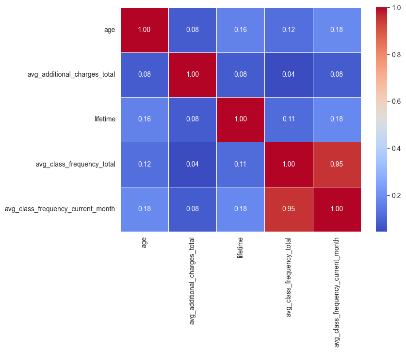

```python
matrix = df[numerical_columns].corr()
plt.figure(figsize=(8,6))
sns.heatmap(matrix, annot=True, cmap="coolwarm", fmt=".2f", linewidths=0.5)
plt.show()
```

There's a very high linear correlation between variables *avg_class_frequency_total* and *avg_class_frequency_current_month*. Before conducting further analysis, it is recommended to exclude one of these variables, as models, especially logistic regression model, might be sensitive to multicollinearity. Other variables are weakly correlated.

### Picking a variable to exclude from the dataset

```python
print("Point-biserial correlation coefficient (churn and avg_class_frequency_total): ",pointbiserialr(df['churn'], df['avg_class_frequency_total']).statistic.round(2))
print("Mean value in groups: ",df.groupby('churn')['avg_class_frequency_total'].mean().round(3))
```

```
Point-biserial correlation coefficient (churn and avg_class_frequency_total):  -0.25
Mean value in groups:  churn
0    2.025
1    1.475
Name: avg_class_frequency_total, dtype: float64
```

```python
print("Point-biserial correlation coefficient (churn and avg_class_frequency_current_month): ",pointbiserialr(df['churn'], df['avg_class_frequency_current_month']).statistic.round(2))
print("Mean value in groups: ",df.groupby('churn')['avg_class_frequency_current_month'].mean().round(3))
```

```
Point-biserial correlation coefficient (churn and avg_class_frequency_current_month):  -0.41
Mean value in groups:  churn
0    2.028
1    1.045
Name: avg_class_frequency_current_month, dtype: float64
```

*Avg_class_frequency_current_month* variable is more strongly related to *churn* variable and it shows greater differences in means between *churn* classes. Therefore variable *avg_class_frequency_total* will be excluded from further analyses.

### Variable distributions in *churn* classes

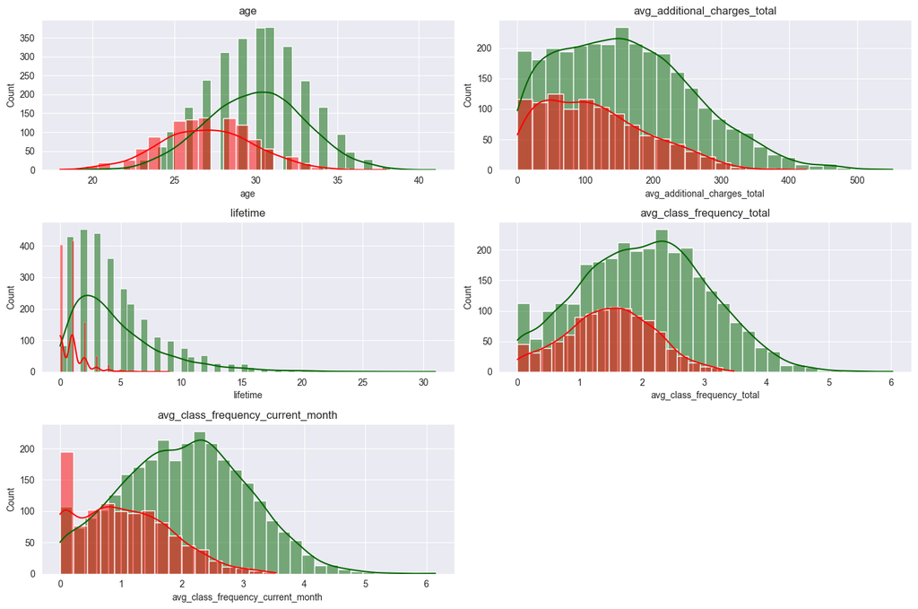

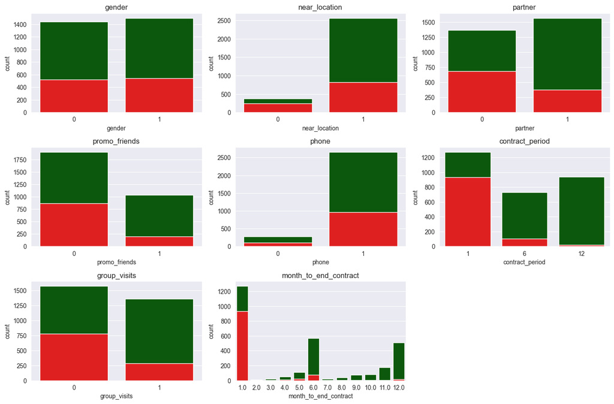

```python
sns.set_style("darkgrid")

churn_0 = df[df['churn']==0]
churn_1 = df[df['churn']==1]

plt.figure(figsize=(14, len(numerical_columns) * 3))
for idx, feature in enumerate(numerical_columns, 1):
    plt.subplot(len(numerical_columns), 2, idx)
    sns.histplot(churn_0[feature], kde=True, color='darkgreen')
    sns.histplot(churn_1[feature], kde=True, color='red')
    plt.title(feature)

plt.tight_layout()
plt.show()


plt.figure(figsize=(14, len(cat_columns) * 3))
for idx, feature in enumerate(cat_columns, 1):
    if (feature!='churn'):
        plt.subplot(len(cat_columns), 3, idx)
        sns.countplot(data=churn_0, x=feature,color='darkgreen')
        sns.countplot(data=churn_1, x=feature,color='red')
        plt.title(feature)

plt.tight_layout()
plt.show()
```

Visible patterns:

- Customers working in partner companies are less likely to churn (if *partner*=0, then *churn*=1 is more likely).
- Most of the churned customers have a one-month contract. Very few customers with 12-month contract churn.
- Churned customers tend to be slightly younger than non-churning customers.
- Churned customers attend classes less frequently. If the customer barely participated in classes in the current month, it is highly probable that they will churn.
- Churned customers have a shorter customer lifetime - members with longer lifetime churn less often.
- Outlying observations almost always refer to non-churning customers (very long customer lifetime, highly frequent participation in classes, high additional costs).

# 4. Data preparation

## 4.1. Dropping multicollinear variables

```python
df.drop('avg_class_frequency_total', axis=1,inplace=True)
outlier_columns.remove('avg_class_frequency_total')
```

## 4.2. Train-test split (80/20)

```python
X = df.drop("churn", axis=1)
y = df['churn']

X_train, X_test, y_train, y_test = train_test_split(X, y, test_size=0.2, random_state=42)
```

## 4.3. Outlier elimination - winsorization

```python
for col in outlier_columns:
    Q1 = X_train[col].quantile(0.25)
    Q3 = X_train[col].quantile(0.75)
    IQR = Q3 - Q1
    lower = Q1-1.5*IQR
    upper = Q3+1.5*IQR

    X_train[col] = np.clip(X_train[col],lower,upper)
    X_test[col] = np.clip(X_test[col],lower,upper)
```

## 4.4. Dataset balancing

To balance the dataset, an undersampling technique was used (as the standard SMOTE method cannot be applied on categorical variables). Given that the majority class consists of non-churning customers and the purpose of the model is to identify churning customers, reducing the size of the majority class should not negatively affect the model's performance.

```python
rus = RandomUnderSampler(random_state=42)
X_train_resampled, y_train_resampled = rus.fit_resample(X_train, y_train)
```

# 5. Modelling

## 5.1. Decision Tree

### 5.1.1. Preliminary model

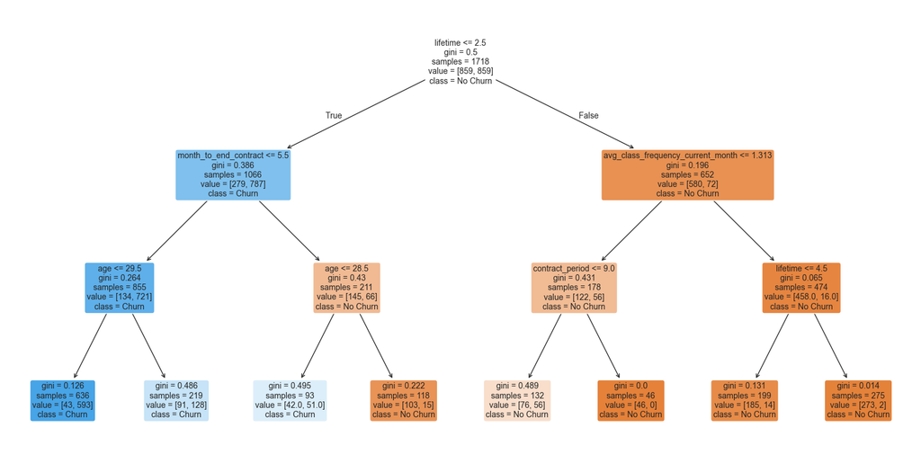

```
Test accuracy: 0.8025
Test recall: 0.9108910891089109
```

```python
dt = DecisionTreeClassifier(max_depth=3,random_state=42)
dt.fit(X_train_resampled, y_train_resampled)
y_pred_dt = dt.predict(X_test)

plt.figure(figsize=(20, 10))
plot_tree(
    dt,
    feature_names=X_train.columns,
    class_names=["No Churn", "Churn"],
    filled=True,
    rounded=True,
    fontsize=10
    )
plt.show()

accuracy_dt = accuracy_score(y_test, y_pred_dt)
print("Test accuracy:", accuracy_dt)
recall_dt = recall_score(y_test, y_pred_dt)
print("Test recall:", recall_dt)
```

### 5.1.2. Hiperparameter tuning

```python
param_grid_dt = {
    'max_depth': [3,5,8],
    'min_samples_leaf': [2,5,10],
    'min_samples_split': [2,5,10],
    'criterion': ["entropy", "gini"]
}

dt = DecisionTreeClassifier(random_state=42)

grid_search = GridSearchCV(estimator=dt, param_grid=param_grid_dt, cv=5, verbose=True, scoring='recall')

grid_search.fit(X_train_resampled, y_train_resampled)

print("best recall", grid_search.best_score_)
print(grid_search.best_estimator_)

dt_best = grid_search.best_estimator_
```

```
Fitting 5 folds for each of 54 candidates, totalling 270 fits
best recall 0.8835917312661499
DecisionTreeClassifier(max_depth=3, min_samples_leaf=2, random_state=42)
```

```python
y_train_pred_dt = dt_best.predict(X_train_resampled)
y_pred_dt = dt_best.predict(X_test)

accuracy_train_dt = accuracy_score(y_train_resampled, y_train_pred_dt)
print("Accuracy (train):",round(accuracy_train_dt,3))
accuracy_test_dt = accuracy_score(y_test, y_pred_dt)
print("Accuracy (test):",round(accuracy_test_dt,3))


recall_train_dt = recall_score(y_train_resampled, y_train_pred_dt)
print("Recall (train):",round(recall_train_dt,3))
recall_test_dt = recall_score(y_test, y_pred_dt)
print("Recall (test):",round(recall_test_dt,3))
```

```
Accuracy (train): 0.847
Accuracy (test): 0.802
Recall (train): 0.899
Recall (test): 0.911
```

Tuned decision tree model shows high accuracy and recall values, but the difference between their train and test value indicate potential overfitting of the model. The most important metric is the *recall*, as it is more important to successfully identify churning customers.

In order to reduce the overfitting of the model and increase its interpretability, the maximum depth of the tree was limited and hiperparameter tuning was performed again.

```python
param_grid_dt = {
    'max_depth': [2,3],
    'min_samples_leaf': [2,5,10],
    'min_samples_split': [2,5,10],
    'criterion': ["entropy", "gini"]
}

dt = DecisionTreeClassifier(random_state=42)

grid_search = GridSearchCV(estimator=dt, param_grid=param_grid_dt, cv=5, verbose=True)

grid_search.fit(X_train_resampled, y_train_resampled)

print("best accuracy", grid_search.best_score_)
print(grid_search.best_estimator_)
```

```
Fitting 5 folds for each of 36 candidates, totalling 180 fits
best accuracy 0.8451539087395755
DecisionTreeClassifier(max_depth=3, min_samples_leaf=2, random_state=42)
```

### 5.1.3. Model evaluation

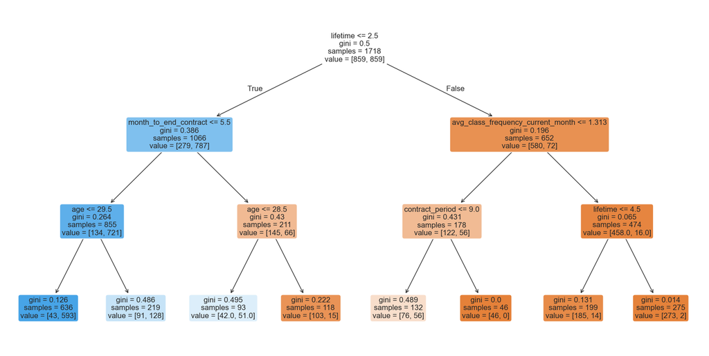

```python
dt_best = grid_search.best_estimator_
plt.figure(figsize=(20,10))
plot_tree(
    dt_best,
    feature_names=X_train_resampled.columns,
    filled=True,
    rounded=True,
    fontsize=12
)
plt.show()
```

```python
y_train_pred_dt = dt_best.predict(X_train_resampled)
y_pred_dt = dt_best.predict(X_test)

accuracy_train_dt = accuracy_score(y_train_resampled, y_train_pred_dt)
print("Accuracy (train):",round(accuracy_train_dt,3))
accuracy_test_dt = accuracy_score(y_test, y_pred_dt)
print("Accuracy (test):",round(accuracy_test_dt,3))


recall_train_dt = recall_score(y_train_resampled, y_train_pred_dt)
print("Recall (train):",round(recall_train_dt,3))
recall_test_dt = recall_score(y_test, y_pred_dt)
print("Recall (test):",round(recall_test_dt,3))
```

```
Accuracy (train): 0.847
Accuracy (test): 0.802
Recall (train): 0.899
Recall (test): 0.911
```

### 5.1.4. Feature importance analysis

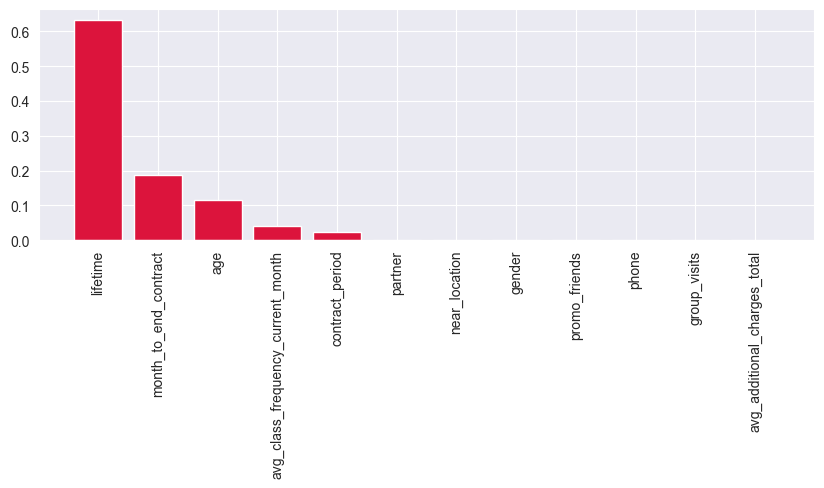

```python
importances_dt = dt_best.feature_importances_
importances_dt_df = pd.DataFrame(importances_dt, index=X_train_resampled.columns, columns=["importance"])

importances_dt_df.sort_values(by='importance',ascending=False,inplace=True)
plt.figure(figsize=(10,3))
plt.bar(x=importances_dt_df.index, height=importances_dt_df['importance'], color='crimson')
plt.xticks(rotation=90)
plt.show()
```

*Lifetime* and *month_to_end_contract* were found to be the most important features in the decision tree model.

## 5.2. Random Forest

### 5.2.1. Preliminary model

```python
rf = RandomForestClassifier()

rf.fit(X_train_resampled, y_train_resampled)
y_pred_rf = rf.predict(X_test)

accuracy_rf = accuracy_score(y_test, y_pred_rf)
print("Test accuracy:", accuracy_rf)
recall_rf = recall_score(y_test, y_pred_rf)
print("Test recall:", recall_rf)
```

```
Test accuracy: 0.8825
Test recall: 0.8811881188118812
```

### 5.2.2. Hiperparameter tuning

```python
param_grid_rf = {
    'n_estimators': [50,100,200,500],
    'max_depth':[3,5,8,12],
    'min_samples_leaf': [2,5,10],
    'min_samples_split': [2,5,10],
    'criterion': ["entropy", "gini"],
    'max_features':['sqrt','log2']
}

rf = RandomForestClassifier(random_state=42)

grid_search = GridSearchCV(estimator=rf, param_grid=param_grid_rf, cv=5, verbose=True, scoring='recall')

grid_search.fit(X_train_resampled, y_train_resampled)

print("best recall", grid_search.best_score_)
print(grid_search.best_estimator_)

rf_best = grid_search.best_estimator_
```

```
Fitting 5 folds for each of 576 candidates, totalling 2880 fits
best recall 0.9103495172038624
RandomForestClassifier(max_depth=8, min_samples_leaf=2, n_estimators=50,
                       random_state=42)
```

### 5.2.3. Model evaluation

```python
y_train_pred_rf = rf_best.predict(X_train_resampled)
y_pred_rf = rf_best.predict(X_test)

accuracy_train_rf = accuracy_score(y_train_resampled, y_train_pred_rf)
print("Accuracy (train):",round(accuracy_train_rf,3))
accuracy_test_rf = accuracy_score(y_test, y_pred_rf)
print("Accuracy (test):",round(accuracy_test_rf,3))

recall_train_rf = recall_score(y_train_resampled, y_train_pred_rf)
print("Recall (train):",round(recall_train_rf,3))
recall_test_rf = recall_score(y_test, y_pred_rf)
print("Recall (test):",round(recall_test_rf,3))
```

```
Accuracy (train): 0.948
Accuracy (test): 0.879
Recall (train): 0.97
Recall (test): 0.911
```

Tuned random forest model shows very high accuracy and recall values - it performs slightly better than decision tree model.

### 5.2.4. Feature importance analysis

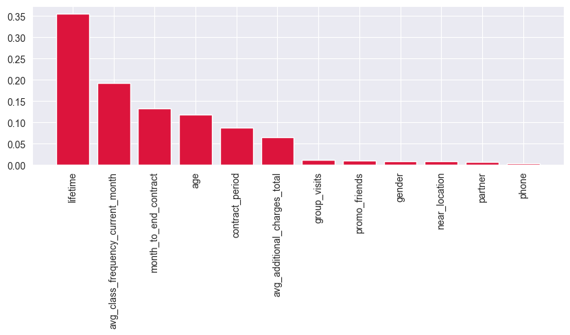

```python
importances = rf_best.feature_importances_
importances_df = pd.DataFrame(importances, index=X_train_resampled.columns, columns=["importance"])

importances_df.sort_values(by='importance',ascending=False,inplace=True)
plt.figure(figsize=(10,3))
plt.bar(x=importances_df.index, height=importances_df['importance'], color='crimson')
plt.xticks(rotation=90)
plt.show()
```

*Lifetime* was found to be the most important variable in the model. Other highly important variables include *avg_class_frequency_current_month*, *age* and *contract_period*, which is consistent with patterns observed in the EDA section.

## 5.3. XGBoost

### 5.3.1. Preliminary model

```python
xgb = XGBClassifier(random_state=42)

xgb.fit(X_train_resampled, y_train_resampled)
y_pred_xgb = xgb.predict(X_test)

accuracy_xgb = accuracy_score(y_test, y_pred_xgb)
print("Test accuracy:", accuracy_xgb)
recall_xgb = recall_score(y_test, y_pred_xgb)
print("Test recall:", recall_xgb)
```

```
Test accuracy: 0.88
Test recall: 0.8762376237623762
```

### 5.3.2. Hiperparameter tuning

```python
param_grid_xgb = {
    'n_estimators': [50,100,500],
    'learning_rate' : [0.05, 0.1],
    'max_depth':[3,5],
    'min_child_weight' : [1, 5]
}


grid_search = GridSearchCV(estimator=xgb, param_grid=param_grid_xgb, cv=5, verbose=True, scoring='recall')

grid_search.fit(X_train_resampled, y_train_resampled)

print("best recall", grid_search.best_score_)
print(grid_search.best_estimator_)

xgb_best = grid_search.best_estimator_
```

```
Fitting 5 folds for each of 24 candidates, totalling 120 fits
best recall 0.9115055079559363
XGBClassifier(base_score=None, booster=None, callbacks=None,
              colsample_bylevel=None, colsample_bynode=None,
              colsample_bytree=None, device=None, early_stopping_rounds=None,
              enable_categorical=False, eval_metric=None, feature_types=None,
              feature_weights=None, gamma=None, grow_policy=None,
              importance_type=None, interaction_constraints=None,
              learning_rate=0.05, max_bin=None, max_cat_threshold=None,
              max_cat_to_onehot=None, max_delta_step=None, max_depth=3,
              max_leaves=None, min_child_weight=1, missing=nan,
              monotone_constraints=None, multi_strategy=None, n_estimators=100,
              n_jobs=None, num_parallel_tree=None, ...)
```

### 5.3.3. Model evaluation

```python
y_train_pred_xgb = xgb_best.predict(X_train_resampled)
y_pred_xgb = xgb_best.predict(X_test)

accuracy_train_xgb = accuracy_score(y_train_resampled, y_train_pred_xgb)
print("Accuracy (train):",round(accuracy_train_xgb,3))
accuracy_test_xgb = accuracy_score(y_test, y_pred_xgb)
print("Accuracy (test):",round(accuracy_test_xgb,3))

recall_train_xgb = recall_score(y_train_resampled, y_train_pred_xgb)
print("Recall (train):",round(recall_train_xgb,3))
recall_test_xgb = recall_score(y_test, y_pred_xgb)
print("Recall (test):",round(recall_test_xgb,3))
```

```
Accuracy (train): 0.924
Accuracy (test): 0.895
Recall (train): 0.939
Recall (test): 0.901
```

Tuned XGBoost model demonstrates very high accuracy and recall values - on the test set it achieves slightly better accuracy, but lower recall compared to the tuned random forest model.

### 5.3.4. Feature importance analysis

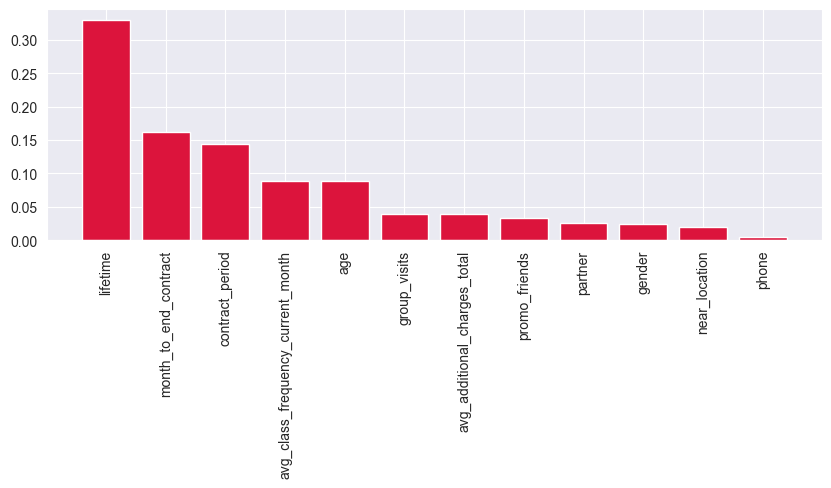

```python
importances = xgb_best.feature_importances_
importances_df = pd.DataFrame(importances, index=X_train_resampled.columns, columns=["importance"])

importances_df.sort_values(by='importance',ascending=False,inplace=True)
plt.figure(figsize=(10,3))
plt.bar(x=importances_df.index, height=importances_df['importance'], color='crimson')
plt.xticks(rotation=90)
plt.show()
```

Similarly to the previous tree models, *Lifetime* was found to be the most important variable in the model. Other highly important variables include *month_to_end_contract*, *age* and *contract_period*, which is consistent with patterns observed in the EDA section.

## 5.4. kNN

### 5.4.1. Standarization

```python
X_train_resampled.columns
```

```
Index(['gender', 'near_location', 'partner', 'promo_friends', 'phone',
       'contract_period', 'group_visits', 'age',
       'avg_additional_charges_total', 'month_to_end_contract', 'lifetime',
       'avg_class_frequency_current_month'],
      dtype='object')
```

```python
scaler = StandardScaler()

stand_columns = ['age','avg_additional_charges_total', 'lifetime',
                 'avg_class_frequency_current_month','contract_period','month_to_end_contract']

X_train_resampled_scaled = X_train_resampled.copy()
X_test_scaled = X_test.copy()
X_train_resampled_scaled[stand_columns] = scaler.fit_transform(X_train_resampled[stand_columns])
X_test_scaled[stand_columns] = scaler.transform(X_test[stand_columns])
```

### 5.4.2. Preliminary model

```python
knn = KNeighborsClassifier(n_neighbors=5)
knn.fit(X_train_resampled_scaled, y_train_resampled)
y_pred_knn = knn.predict(X_test_scaled)

accuracy_knn = accuracy_score(y_test, y_pred_knn)
print("Test accuracy", accuracy_knn)
recall_knn = recall_score(y_test, y_pred_knn)
print("Test recall", recall_knn)
```

```
Test accuracy 0.865
Test recall 0.900990099009901
```

### 5.4.3. Hiperparameter tuning

```python
param_grid_knn = {
    "n_neighbors":range(1,11),
    "metric":["euclidean","manhattan"]
    }

knn = KNeighborsClassifier()

grid_search = GridSearchCV(estimator=knn, param_grid=param_grid_knn, cv=5, verbose=True, scoring='recall')

grid_search.fit(X_train_resampled_scaled, y_train_resampled)

print("best recall", grid_search.best_score_)
print(grid_search.best_estimator_)

knn_best = grid_search.best_estimator_
```

```
Fitting 5 folds for each of 20 candidates, totalling 100 fits
best recall 0.9312865497076024
KNeighborsClassifier(metric='manhattan', n_neighbors=9)
```

### 5.4.4. Model evaluation

```python
y_train_pred_knn = knn_best.predict(X_train_resampled_scaled)
y_pred_knn = knn_best.predict(X_test_scaled)

accuracy_train_knn = accuracy_score(y_train_resampled, y_train_pred_knn)
print("Accuracy (train):",round(accuracy_train_knn,3))
accuracy_test_knn = accuracy_score(y_test, y_pred_rf)
print("Accuracy (test):",round(accuracy_test_knn,3))

recall_train_knn = recall_score(y_train_resampled, y_train_pred_knn)
print("Recall (train):",round(recall_train_knn,3))
recall_test_knn = recall_score(y_test, y_pred_knn)
print("Recall (test):",round(recall_test_knn,3))
```

```
Accuracy (train): 0.896
Accuracy (test): 0.879
Recall (train): 0.935
Recall (test): 0.911
```

K-nearest neighbors model shows very high accuracy and recall values, with indication of potential very slight overfitting. The kNN model does not allow to analyze the individual feature importances, as predictions are based on the classes of most similar observations.

## 5.5. Logistic Regression

### 5.5.1. Preliminary model

```python
lr = LogisticRegression(solver='liblinear', max_iter=1000)

lr.fit(X_train_resampled_scaled, y_train_resampled)
y_pred_lr = lr.predict(X_test_scaled)

accuracy_lr = accuracy_score(y_test, y_pred_lr)
print("Test accuracy: ",accuracy_lr)
recall_lr = recall_score(y_test, y_pred_lr)
print("Test recall: ",recall_lr)
```

```
Test accuracy:  0.9075
Test recall:  0.9306930693069307
```

### 5.5.2. Hiperparameter tuning

```python
param_grid_lr = {
    "penalty": ['l1','l2'],
    "C" : [0.01, 0.1, 1, 10, 100, 1000]
}
```

```python
lr = LogisticRegression(random_state=42, max_iter=1000, solver='liblinear')

grid_search = GridSearchCV(estimator=lr, param_grid=param_grid_lr, scoring='recall')

grid_search.fit(X_train_resampled_scaled, y_train_resampled)

print("best recall", grid_search.best_score_)
print(grid_search.best_estimator_)

lr_best = grid_search.best_estimator_
```

```
best recall 0.9615531075751393
LogisticRegression(C=0.01, max_iter=1000, penalty='l1', random_state=42,
                   solver='liblinear')
```

### 5.5.3. Model evaluation

```python
y_train_pred_lr = lr_best.predict(X_train_resampled_scaled)
y_pred_lr = lr_best.predict(X_test_scaled)

accuracy_train_lr = accuracy_score(y_train_resampled, y_train_pred_lr)
print("Accuracy (train):",round(accuracy_train_lr,3))
accuracy_test_lr = accuracy_score(y_test, y_pred_lr)
print("Accuracy (test):",round(accuracy_test_lr,3))

recall_train_lr = recall_score(y_train_resampled, y_train_pred_lr)
print("Recall (train):",round(recall_train_lr,3))
recall_test_lr = recall_score(y_test, y_pred_lr)
print("Recall (test):",round(recall_test_lr,3))
```

```
Accuracy (train): 0.886
Accuracy (test): 0.86
Recall (train): 0.96
Recall (test): 0.96
```

### 5.5.4. Feature importance analysis - odds ratios

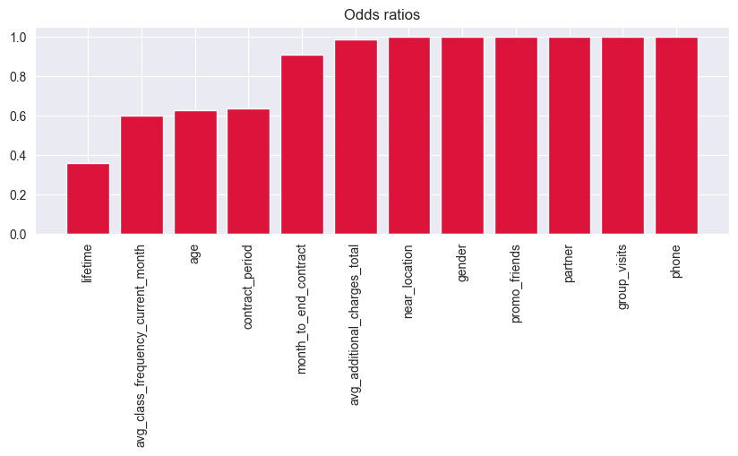

```python
coefficients = lr_best.coef_[0]
odds_ratios = np.exp(coefficients)

importances_df = pd.DataFrame({
    'feature': X_train_resampled.columns,
    'coefficient': coefficients,
    'abs_coefficient': np.abs(coefficients),
    'odds_ratio': odds_ratios,
    'percent_change' : np.abs(odds_ratios-1)
})

importances_df.sort_values(by="percent_change",ascending=False, inplace=True)

plt.figure(figsize=(10,3))
plt.bar(x=importances_df['feature'], height=importances_df['odds_ratio'], color='crimson')
plt.title("Odds ratios")
plt.xticks(rotation=90)
plt.show()
```

# 6. Results comparison

```python
results_df = pd.DataFrame({
    "accuracy_train": [accuracy_train_dt, accuracy_train_rf, accuracy_train_xgb, accuracy_train_knn, accuracy_train_lr],
    "accuracy_test": [accuracy_test_dt, accuracy_test_rf, accuracy_test_xgb, accuracy_test_knn, accuracy_test_lr],
    "recall_train":[recall_train_dt, recall_train_rf, recall_train_xgb, recall_train_knn, recall_train_lr],
    "recall_test":[recall_test_dt, recall_test_rf, recall_test_xgb, recall_test_knn, recall_test_lr]},
    index=[
    "Decision Tree",
    "Random Forest",
    "XGBoost",
    "kNN",
    "Logistic Regression"]
)
```

```python
results_df.sort_values(by='recall_test', ascending=False)
```

|  | accuracy_train | accuracy_test | recall_train | recall_test |
| --- | --- | --- | --- | --- |
| Logistic Regression | 0.885914 | 0.86000 | 0.960419 | 0.960396 |
| Decision Tree | 0.846915 | 0.80250 | 0.898719 | 0.910891 |
| Random Forest | 0.948196 | 0.87875 | 0.969732 | 0.910891 |
| kNN | 0.896391 | 0.87875 | 0.934808 | 0.910891 |
| XGBoost | 0.923749 | 0.89500 | 0.939464 | 0.900990 |

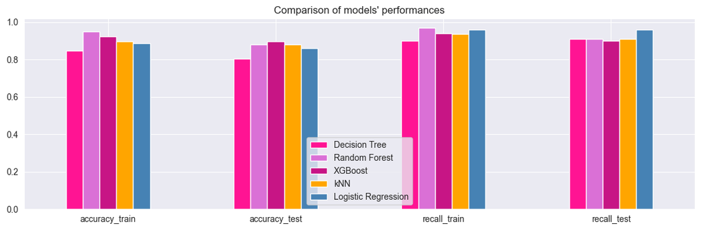

```python
results_df.T.plot(
    kind='bar',
    figsize=(14, 4),
    color=["deeppink","orchid","mediumvioletred","orange","steelblue"]
)

plt.xticks(rotation=0)
plt.title("Comparison of models' performances")
plt.show()
```

Each of the analyzed models allowed to successfully classify observations in both the train and the test datasets. The best results on the **train** dataset were achieved by the **Random Forest** model. However, on the **test** dataset the best accuracy was demonstrated by the **XGBoost** model and the best recall - by the **Logistic Regression** model.  
Taking into consideration that the recall metric on the test dataset is the most important measure in the churn analysis, the **Logistic Regression** model can be picked as the best model.

# 7. The final model

The final Logistic Regression model achieves accuracy and recall values above >0.85, on both the train and the test datasets. In this section SHAP profiles of the final model are shown, in order to demonstrate the model's performance in regard to the individual customers.

## 7.1. Individual SHAP profiles

The logistic regression model expresses the log-odds of the positive outcome as a linear combination of the predictors. Therefore SHAP profiles for this type of model describe additive contribution of each variable on the log-odds of the occurence of positive class. Negative values of log-odds indicate that the probability of the positive class is lower than 50% (predicted class = 0). Positive values, on the contrary, indicate the probability of the positive class greater than 50% (predicted class = 1). Moreover, the model was estimated on the standardized values of the predictors. However, for the sake of easier interpretation, SHAP profiles present untransformed values of the predictor variables.

```python
explainer = shap.LinearExplainer(lr_best, X_train_resampled_scaled)
shap_values = explainer(X_test_scaled)
shap.initjs()
```

```python
shap_values.feature_names = X_test.columns.tolist()
shap_values.data = X_test.values
```

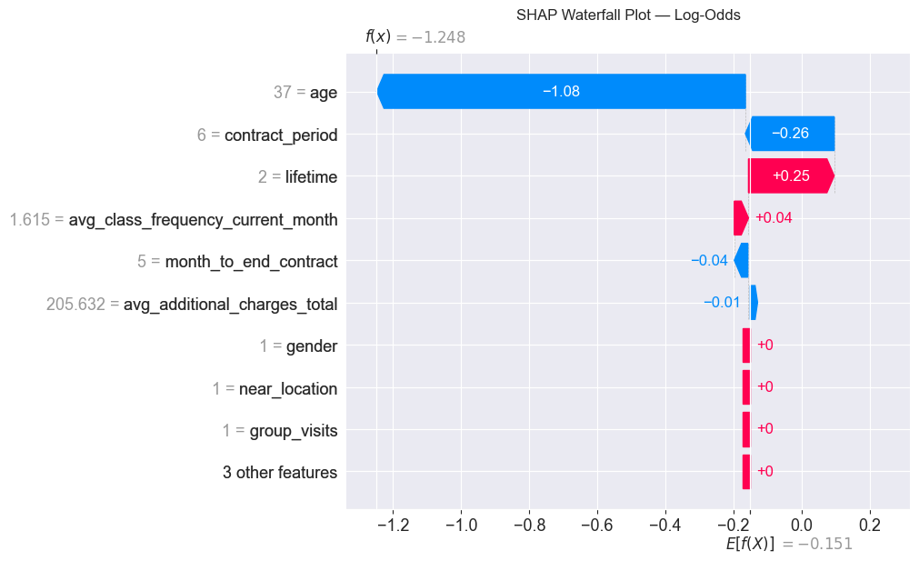

```python
shap.waterfall_plot(shap_values[0,:],show=False)
plt.title("SHAP Waterfall Plot — Log-Odds")
plt.show()
```

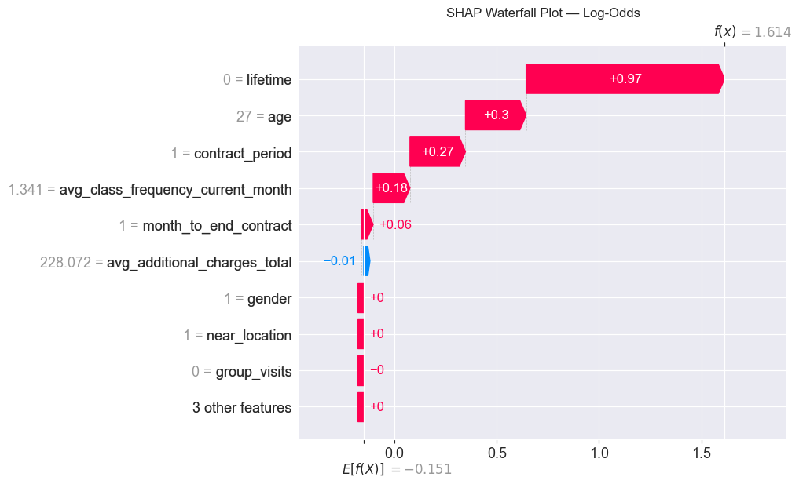

```python
shap.waterfall_plot(shap_values[5,:], show=False)
plt.title("SHAP Waterfall Plot — Log-Odds")
plt.show()
```

The second presented SHAP profile shows the result of the model for the customer classified as churning (*churn* = 1). Once again, the main variables impacting the result were *lifetime*, *age* and *contract_period*. Due to the lack of customer's lifetime, their young age (27 years old), an only 1-month contract period and infrequent participation in classes in the current month, their chances of churning are high. The amount of customer's additional charges lowers the chances of them churning, but its contribution to the overall prediction is marginal.

## 7.2. Summary SHAP profile

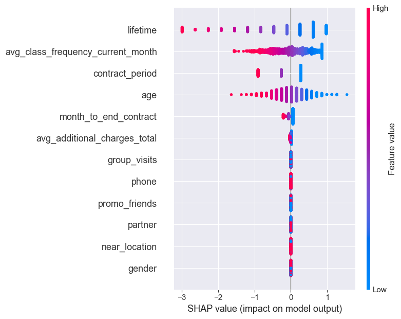

```python
shap.summary_plot(shap_values, X_test_scaled)
plt.show()
```

SHAP Summary Plot

- Lower values of the *lifetime* variable increase the log-odds (and therefore probability) of the customer churning.
- Similarly, less frequent participation in classes and short contract periods correspond to higher log-odds of the customer's churn.
- Younger customers have higher log-odds of churning.

# Summary

The purpose of the project was to build a classification model, which would successfully predict the churn of the gym customers. The dataset used in the analysis exhibited significant class imbalance, included outliers as well as multicollinear variables. As part of the project, performances of 5 classification models were compared: decision tree, random forest, XGBoost, k-nearest neighbors and logistic regression. In each case hiperparameter tuning of the model was conducted. Each of the trained models exhibited high predictive abilities, both on the train and the test dataset (accuracy and recall values around 0.8-0.9). The best-performing model was the logistic regression model, which allowed to make predictions with accuracy over 0.85 and recall over 0.95 on both train and test datasets. Features most significantly impacting the churn prediction turned out to be:

- a customer's lifetime - customers with longer lifetime tend to churn less,
- a frequency of class attendance in the current month - customers who rarely attended classes in the recent time are more likely to churn,
- a length of the contract period - short contract periods can be associated with churning customers,
- a customer's age - younger customers tend to churn more than the older ones,
- time left until the end of the contract period - customers with expiring contract are more likely to churn.

Similar conclusions could also be drawn based on the decision tree, random forests and XGBoost models. These patterns allow the gym's management to identify the potential churning customers and take appropriate measures to prevent their resignation.